# Basic Plots in ggplot2

2018-05-15

## Let’s Run the Setup File…

Copy and paste the code below into your console. Run the code in the file that opens.

```r
curl::curl_download(
  "https://raw.githubusercontent.com/heike/summerschool-2018/master/02-graphics/code/0-Setup.R",
  "0-Setup.R"
)
file.edit("0-Setup.R")
```

You should see a plot appear if setup is successful.

## ggplot2 in a nutshell

- Wildly popular package for statistical graphics: by now about 400k monthly downloads from CRAN ( more than 10k times per day)

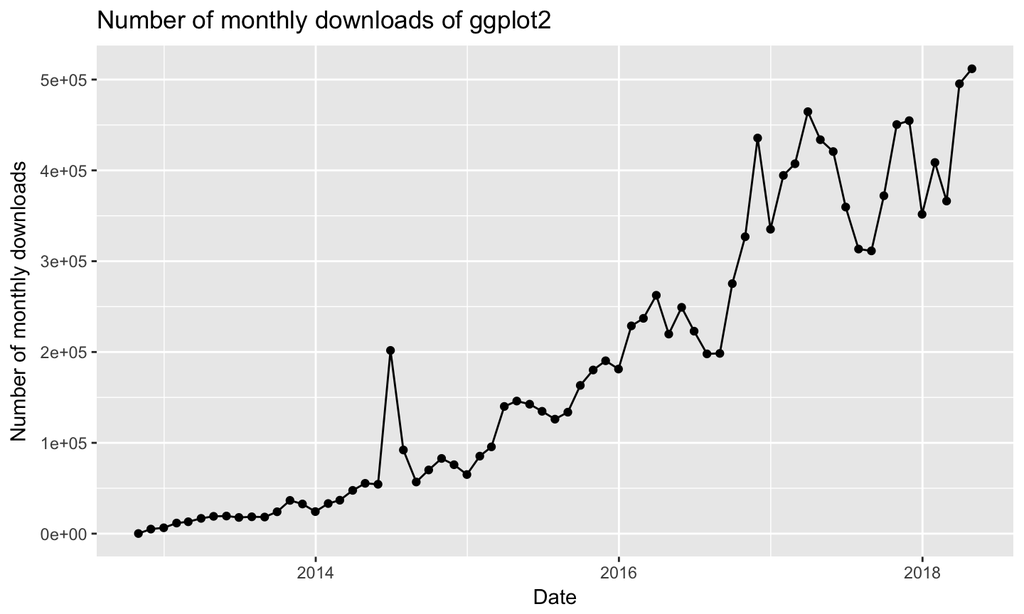

## More on ggplot2

- Developed by Hadley Wickham (An ISU Alumni)
- Designed to adhere to good graphical practices
- Supports a wide variety plot types
- Constructs plots using the concept of layers
- http://ggplot2.org/book/ or Hadley’s book *ggplot2: Elegant Graphics for Data Analysis* for reference material

## *qplot* Function

The *qplot()* function is the basic workhorse of ggplot2

- Produces all plot types available with ggplot2
- Allows for plotting options within the function statement
- Creates an object that can be saved
- Plot layers can be added to modify plot complexity

## *qplot* Structure

The *qplot()* function has a basic syntax:

*qplot(variables, plot type, dataset, options)*

- variables: list of variables used for the plot
- plot type: specified with a *geom =* statement
- dataset: specified with a *data =* statement
- options: there are so, so many options!

## Diamonds Data

We will explore the diamonds data set (preloaded along with ggplot2) using qplot for basic plotting.

The data set was scraped from a diamond exchange company data base by Hadley. It contains the prices and attributes of over 50,000 diamonds

## Examining the Diamonds Data

What does the data look like?

Lets look at the top few rows of the diamond data frame to find out!

```r
head(diamonds)
```

```
## # A tibble: 6 x 10
##   carat cut       color clarity depth table price     x     y     z
##   <dbl> <ord>     <ord> <ord>   <dbl> <dbl> <int> <dbl> <dbl> <dbl>
## 1 0.230 Ideal     E     SI2      61.5  55.0   326  3.95  3.98  2.43
## 2 0.210 Premium   E     SI1      59.8  61.0   326  3.89  3.84  2.31
## 3 0.230 Good      E     VS1      56.9  65.0   327  4.05  4.07  2.31
## 4 0.290 Premium   I     VS2      62.4  58.0   334  4.20  4.23  2.63
## 5 0.310 Good      J     SI2      63.3  58.0   335  4.34  4.35  2.75
## 6 0.240 Very Good J     VVS2     62.8  57.0   336  3.94  3.96  2.48
```

## Basic Scatterplot

Basic scatter plot of diamond price vs carat weight

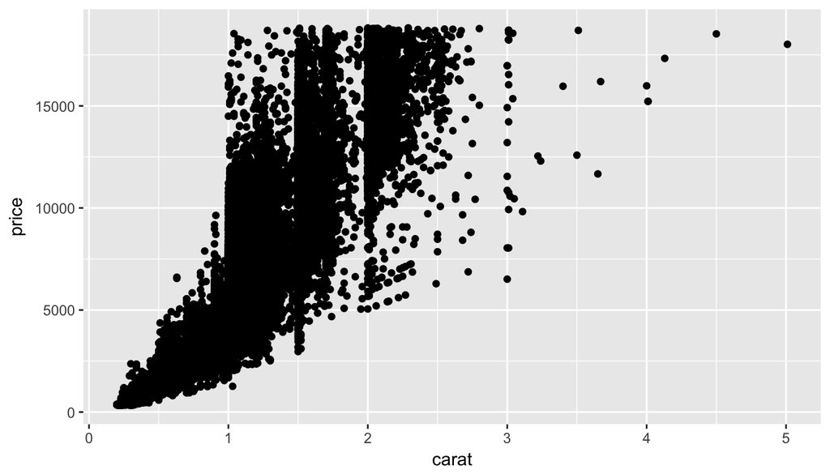

```r
qplot(carat, price, geom = "point", data = diamonds)
```

## Basic Scatterplot (2)

Using alpha-blending helps with the overplotting

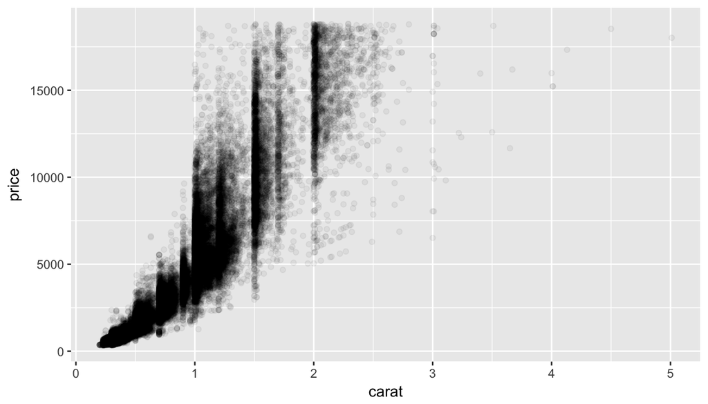

```r
qplot(carat, price, geom = "point", data = diamonds, alpha = I(0.05))
```

## Basic Scatterplot (3)

log-transformation and color

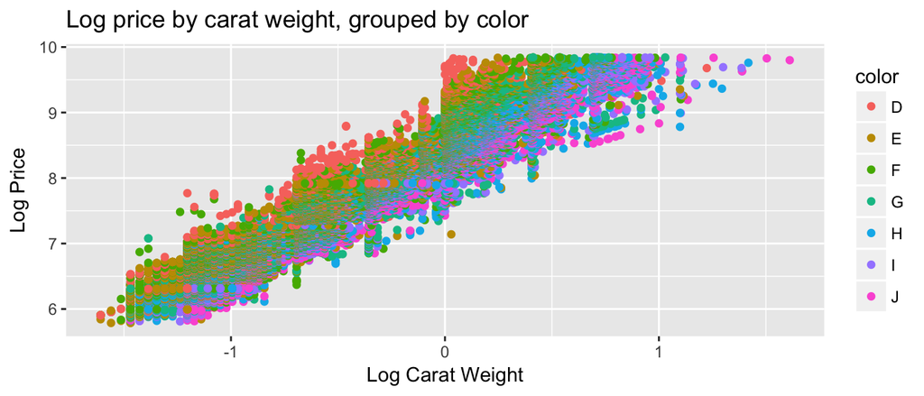

```r
qplot(log(carat), log(price), geom = "point", data = diamonds,
    colour = color,
    main = "Log price by carat weight, grouped by color") +
    xlab("Log Carat Weight") + ylab("Log Price")
```

## Your Turn

The Behavioral Risk Factor Surveillance System (BRFSS) is an annual survey provided by the Center for Disease Control (CDC) to assess behavioral and chronic diseases. The center surveys six individual-level behavioral health risk factors associated with the leading causes of premature mortality and morbidity among adults: 1) cigarette smoking, 2) alcohol use, 3) physical activity, 4) diet, 5) hypertension, and 6) safety belt use.

A codebook describing the survey and a listing of all variables is available at http://www.cdc.gov/brfss/annual_data/2012/pdf/CODEBOOK12_LLCP.pdf.

## Your Turn

```r
iowa <- read.csv("https://raw.githubusercontent.com/heike/summerschool-2018/master/02-graphics/data/brfss-iowa-2012.csv")
```

1. Use `qplot` to build a scatterplot of variables `WTKG3` (weight in kg) and `HTIN4` (height in inch)
2. Use options within `qplot` to color points by a person’s gender (`SEX`)
3. Clean up axis labels and add main plot title

## Basic Histogram

Basic histogram of price

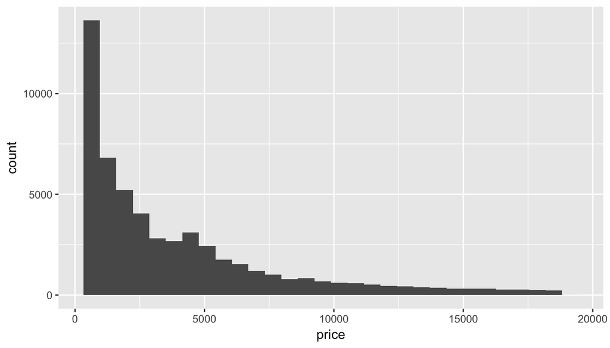

```r
qplot(price, geom = "histogram", data = diamonds)
```

## Why setting the bin width is useful

Histogram of price, binwidth is set to $50

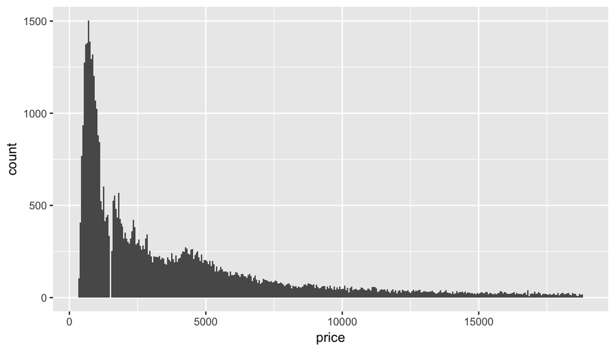

```r
qplot(price, geom = "histogram",  binwidth = 50, data = diamonds)
```

## Another Histogram

Price histograms faceted by clarity

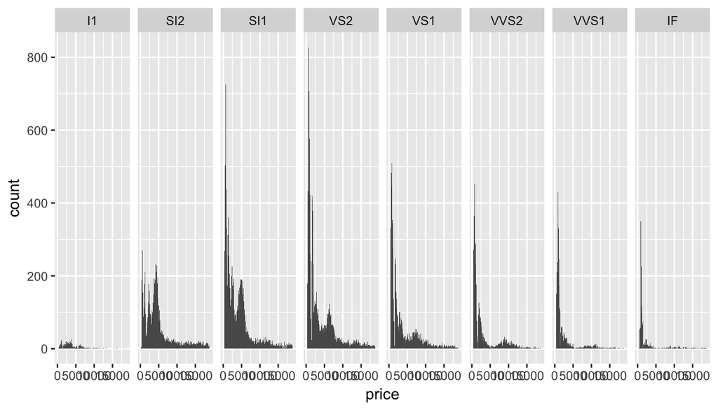

```r
qplot(price, geom = "histogram", data = diamonds, binwidth = 100, facets = .~clarity)
```

## Your Turn

1. Create a new variable in the brfss data calculating bmi: bmi = (weight in kg) / (height in m)^2
2. Use qplot to create a histogram of bmi
3. Change the bin width on that histogram to 1
4. Facet this histogram by gender

## Basic Boxplot

Side by side boxplot of diamond prices within clarity groupings

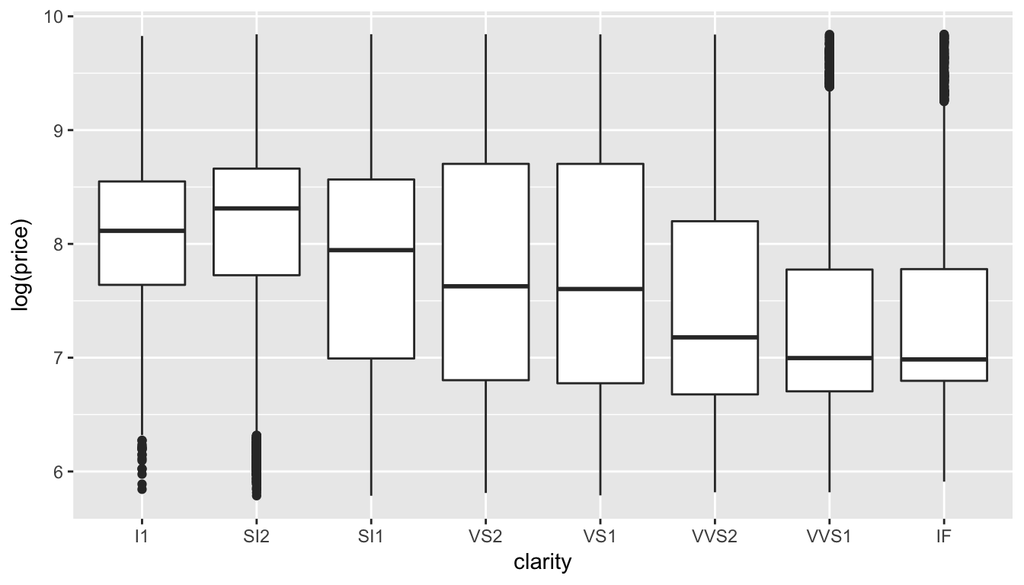

```r
qplot(clarity, log(price), geom = "boxplot", data = diamonds)
```

Why does price decrease as the quality of the diamonds increases?

## Another Boxplot

Side by side boxplot of log prices within clarity groupings with jittered values overlay

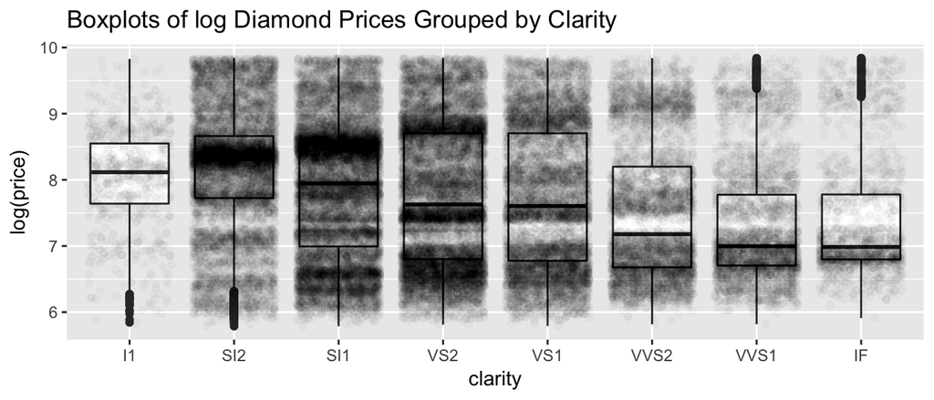

```r
qplot(clarity, log(price), geom = "boxplot", data = diamonds,
    main = "Boxplots of log Diamond Prices Grouped by Clarity") +
    geom_jitter(alpha = I(.025))
```

There are two groups of prices … maybe related to size?

## Another Boxplot

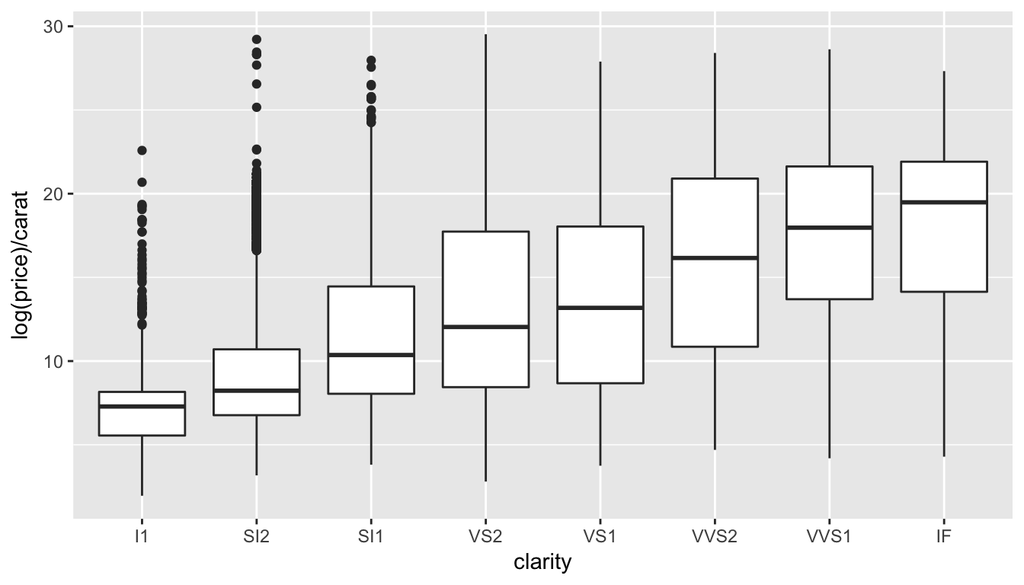

```r
qplot(clarity, log(price)/carat, geom = "boxplot", data = diamonds)
```

## Your Turn

Binge drinking - is defined as 5 or more alcoholic drinks for men or 4 or more drinks for women on one occasion.

1. The variable `DRNK3GE5` captures the number of times in the last 30 days that respondents binge drank. Draw side-by-side boxplots of `DRNK3GE5` for genders (`SEX`).
2. It turns out that values 88, 99 and 77 have special meaning: 88 stands for “none”, 99 is “refused to answer” and 77 is “not sure”. Exclude these values from the boxplot.
3. Overlay jittered points for observed values onto this boxplot

## Bar Plots

To investigate bar plots we will switch over to the Titanic data set:

```r
titanic <- as.data.frame(Titanic)
```

Data includes passenger characteristics and survival outcomes for those aboard the RMS Titanic’s ill fated maiden voyage

## Basic Bar Plot

Basic bar plot of survival outcomes

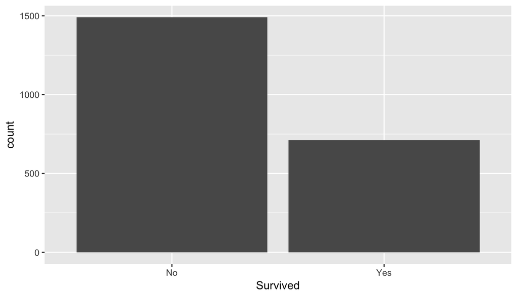

```r
qplot(Survived, geom = "bar", data = titanic, weight = Freq)
```

## Another Bar Plot

Bar plot faceted by gender and class

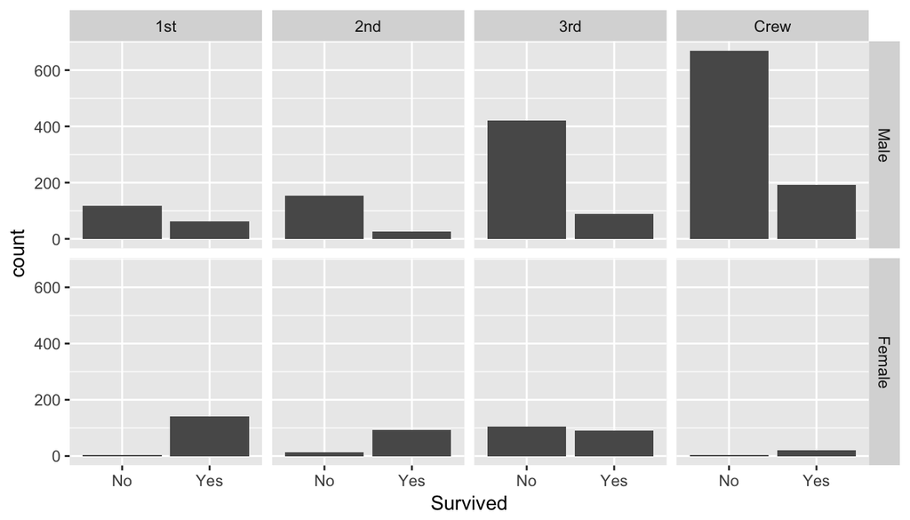

```r
qplot(Survived, geom = "bar", data = titanic, weight = Freq,
      facets = Sex~Class)
```

## Your Turn

Who uses their seatbelts?

1. Use the brfss data to make a barplot for counts of seatbelt use (SEATBELT). *Seatbelt use (SEATBELT) is captured as 1 - Always, 2- Nearly Always, 3-Sometimes, 4- Seldom, 5-Never, 7-Don’t know, 8-Never drive or ride in a car, 9-Refused, to BLANK-Missing.*
2. Facet seatbelt use by gender - are there gender differences in usage?